# Use R to visualize the results of your meta-analysis

26 October 2017

## R to visualize your data

## Why visualize your data?

- summarize information
- check assumptions validity
- many pieces of information at one glance
- ease the understanding

## Why use R to do it?

### Workflow

## Why use R to do it?

### Workflow

## Why use R to do it?

Here we'll argue why use R for doing your plots:

- visualizing data
- what makes a good graph (some details)
- work-flow (data are already in R)
- base graph / ggplot2 / web graphs (interacting)
- code / reproducible

## Why use R to do it?

### Many ways to visualize

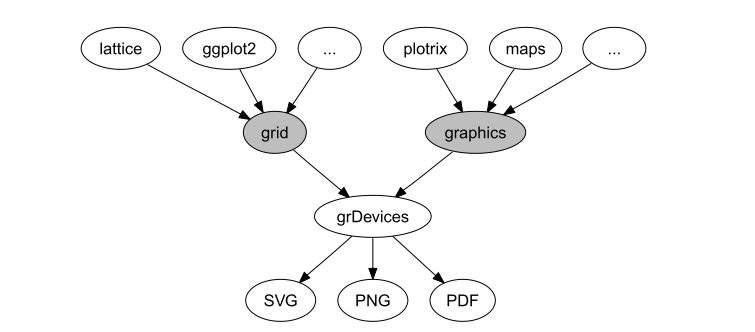

- The gridGraphics package
- Web-based graphs

## Why use R to do it?

### Many, many, many packages available

- http://blog.revolutionanalytics.com/2017/01/cran-10000.html
- https://stackoverflow.blog/2017/10/10/impressive-growth-r/
- [click here Kev](http://revolution-computing.typepad.com/.a/6a010534b1db25970b01b8d2594d25970c-pi)

## Why use R to do it?

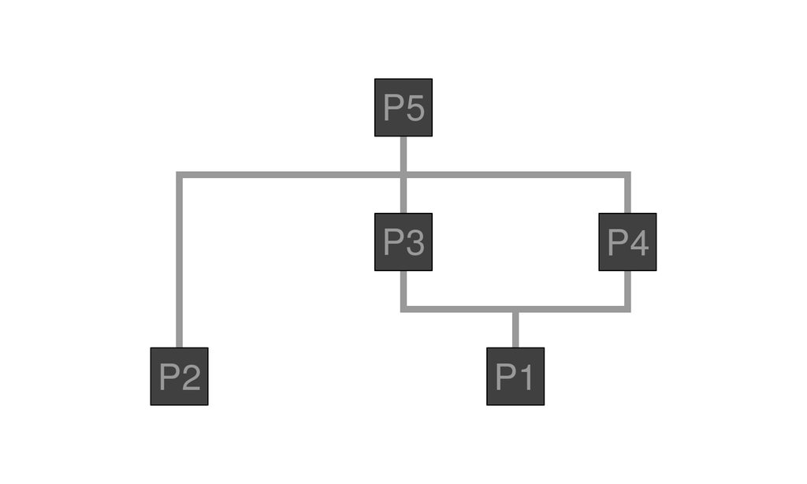

## Why use R to do it?

### Few lines of codes

```r
library(raster)
library(mapview)
elvBtn = getData('alt', country='BTN', path='./assets/')
mapview(elvBtn)
```

## Why use R to do it?

### Few lines of codes

[interactive chart not shown]

## Why use R to do it?

### A large community

## Why use R to do it?

[figure not shown]

## Common plots used in meta-analyses with R

## What do we want/need to visualize?

1. **Effect size**:
- log risk ratios
- log odds ratios
- risk differences
- mean differences,
- standardized mean differences
- …
1. **Number of study**:
- by author
- by region
- by species

### Effect size

https://en.wikipedia.org/wiki/Effect_size#Difference_family:_Effect_sizes_based_on_differences_between_means

- against
- studies + results
- aim?
- effect size
- risk ratio
- influence of certain study/author/group/country

## Use R

## R packages for meta-analyses

- [click here kev](https://cran.r-project.org/web/views/MetaAnalysis.html)
- `install.packages("ctv"); ctv::install.views("MetaAnalysis")`

## Meta vs Metafor

- Guido Schwarzer author of [`meta`](https://cran.r-project.org/web/packages/meta/meta.pdf)
- Schwarzer, Guido, James R. Carpenter, and Gerta Rücker. [Meta-Analysis with R](http://www.springer.com/us/book/9783319214153).
- Wolfgang Viechtbauer author [`metafor`](https://cran.r-project.org/web/packages/metafor/metafor.pdf)
- [click here kev](http://www.metafor-project.org/doku.php/plots)

## Meta vs Metafor

## Problem!

- Everything you need is online
- A problem… just google it!
- **How can we help you?**
- [click here kev](http://www.metafor-project.org/doku.php/plots)

## Install packages

```r
install.packages('metafor')
library('metafor')
```

## `rma()`

```r
?rma
```

## Funnel plot

## Funnel plot

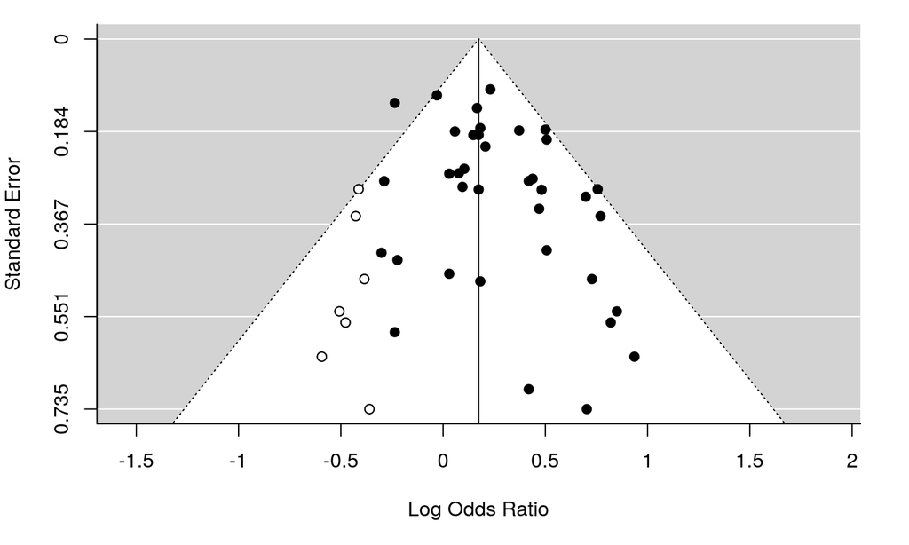

## Funnel plot – version 2

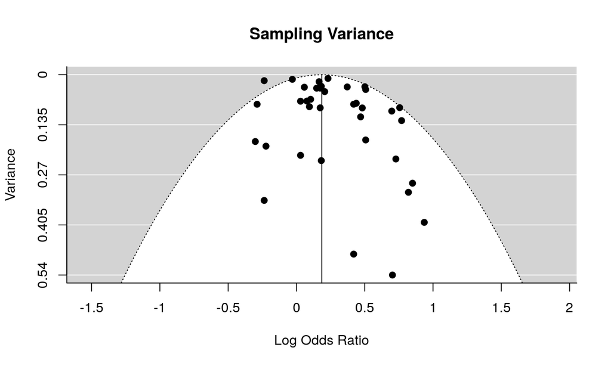

## Funnel plot – version 3

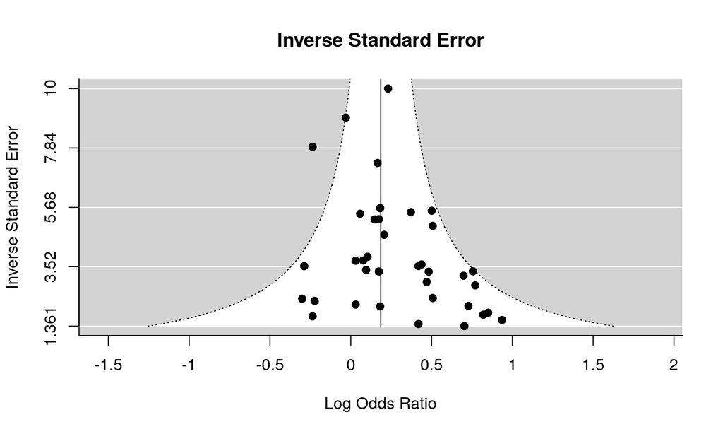

## Forest plot

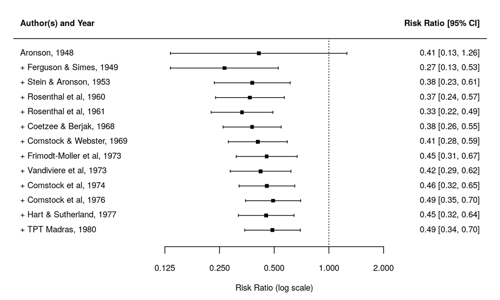

## Custom your plot

## Few tips

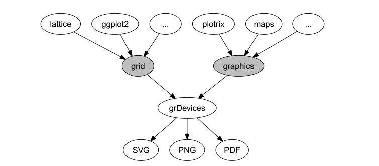

## Few tips

- Axis
- Legend
- points
- lines
- colors
- text

## Let's practice

## Reproduce the figures in Vellend et al. 2013

Paper is available on line

## Figure 2

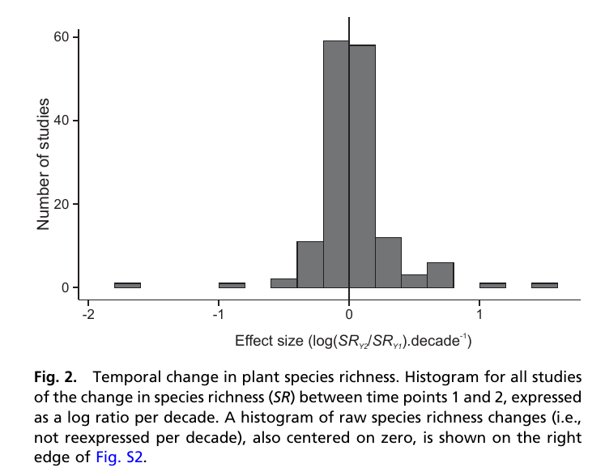

## Figure 3

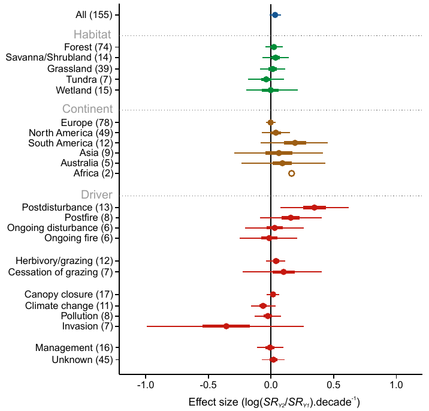

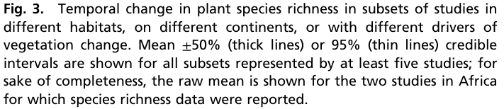

## Let's have some fun

## WordCloud

```r
library(wordcloud2)
wordcloud2(demoFreq)
wordcloud2(demoFreq, size = 2)
```

https://github.com/inSileco/wordcloud/blob/master/ourWordcloud.R

## WordCloud

[interactive chart not shown]

## Network of co-authors

[interactive chart not shown]

igraph

## Resources

## Useful links

- [task view on CRAN](https://cran.r-project.org/web/views/MetaAnalysis.html)
- at least 2 books:
1. Chen, Ding-Geng, and Karl E. Peace. [Applied Meta-Analysis with R](https://www.crcpress.com/Applied-Meta-Analysis-with-R/Chen-Peace/p/book/9781466505995). Chapman & Hall/CRC Biostatistics Series. Boca Raton: CRC Press/Taylor & Francis Group, 2013. + companion website
2. Schwarzer, Guido, James R. Carpenter, and Gerta Rücker. [Meta-Analysis with R](http://www.springer.com/us/book/9783319214153). Use R! Cham: Springer International Publishing, 2015. https://doi.org/10.1007/978-3-319-21416-0.